# Ford GoBike System Data Exploration

## by Imesha Kuruppu

## Investigation Overview

> In this investigation, I wanted to analyze user behavior affecting the use of the GoBike system. The investigation is done to find in which situations bike usage is high and how average trip duration varies with the user characteristics. The main focus is given to find characteristics(user type, age, gender) of users and analyze how average trip duration and demand for bikes varies with those characteristics.

## Dataset Overview

> Initially, this data-set included 183412 rows and 16 columns. This dataset has bike-sharing data of February month in 2019. After the preliminary data-wrangling, this data set included data for 174952 bike trips along with 16 columns. For each bike trip, it included information about the trip duration, start/end time, start/end station id and name, bike id, user type, member birth year, and member gender. 'start_date', 'start_day', 'start_hour', 'duration_min', and 'user_age' columns derived from existing columns.

## Bike usage by user type

> There are two types of users in this dataset, they are Subscribers and Customers. Plotting a pie chart to find on what percentage each user type use the bike-sharing system. 90.4% of users are subscribers and 9.6% users are customers.

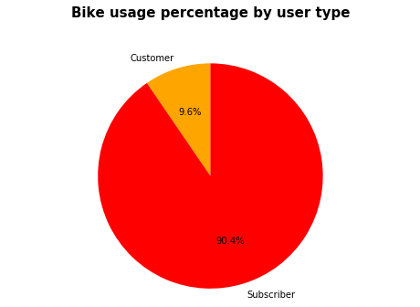

```python
Customer = bike_data_copy.query('user_type == "Customer"').shape[0]
Subscriber = bike_data_copy.query('user_type == "Subscriber"').shape[0]

customer_percentage = (Customer / bike_data_copy.shape[0]) * 100
subscriber_percentage = (Subscriber / bike_data_copy.shape[0]) * 100

labels = ['Customer', 'Subscriber']
sizes = [customer_percentage, subscriber_percentage]
colors = ['orange', 'red']

plt.figure(figsize=[8, 5])
plt.pie(sizes, labels=labels, colors = colors, autopct='%1.1f%%', startangle=90)
plt.axis('equal')

plt.title('Bike usage percentage by user type', fontsize=15, fontweight='bold', y=1.12);
```

## Distribution of trip duration

> Trip duration in the dataset is plotted on a logarithmic scale. From the graph, we can find that the most common trip duration is 10 mins.

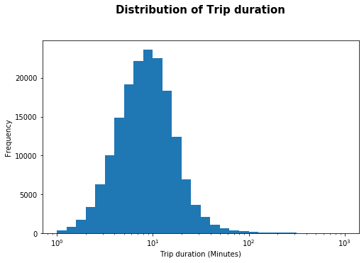

```python
# Investigating the distribution of trip duration
plt.figure(figsize=[8, 5])
bins = 10**np.arange(0 , 3+0.1 , 0.1)
ticks =  [0.1, 0.3, 1 , 3, 10, 30, 100, 300]
labels = ['{}'.format(v) for v in ticks]
plt.hist(data = bike_data_copy , x = 'duration_min' , bins = bins);
plt.xticks(ticks,labels);
plt.title('Distribution of Trip duration', fontsize=15, fontweight='bold', y=1.12)
plt.xlabel('Trip duration (Minutes)');
plt.ylabel('Frequency')
plt.xscale('log');
```

## Average trip duration by user type

> When we plot the average trip duration for each user type, we can recognize that customers use bikes for longer trips than subscribers.

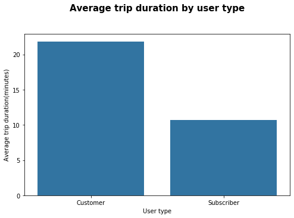

```python
# Investigating the average trip duration of each user type.
df_bike_data_user_duration = bike_data_copy.groupby('user_type')['duration_min'].mean().reset_index()
plt.figure(figsize=[8, 5])
sb.barplot(data=df_bike_data_user_duration, x='user_type', y='duration_min', color = base_color)
plt.title('Average trip duration by user type', fontsize=15, fontweight='bold', y=1.12)
plt.xlabel('User type')
plt.ylabel('Average trip duration(minutes)')
plt.show();
```

## Average trip duration during the week by user type

> During the week customers' average trip duration is always higher than subscribers'. During the weekend both users' trip duration increases when compared to weekdays.

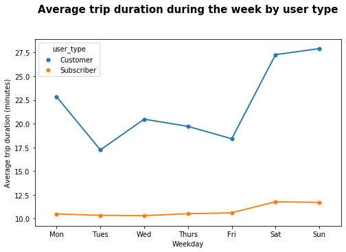

```python
# Investigating the average trip duration during the week by user type
df_weekday_avg_duration = bike_data_copy.groupby(['start_day', 'user_type'])['duration_min'].mean().reset_index()
plt.figure(figsize=[8, 5])
sb.pointplot(data=df_weekday_avg_duration, x='start_day', y='duration_min' , hue = 'user_type', scale=.7)
ticks =  [0,1,2,3,4,5,6]
labels = ['Mon', 'Tues', 'Wed', 'Thurs', 'Fri', 'Sat', 'Sun']
plt.xticks(ticks,labels)
plt.title('Average trip duration during the week by user type', fontsize=15, fontweight='bold', y=1.12)
plt.xlabel('Weekday')
plt.ylabel('Average trip duration (minutes)')
plt.show();
```

## Average trip duration by age vs gender vs user type

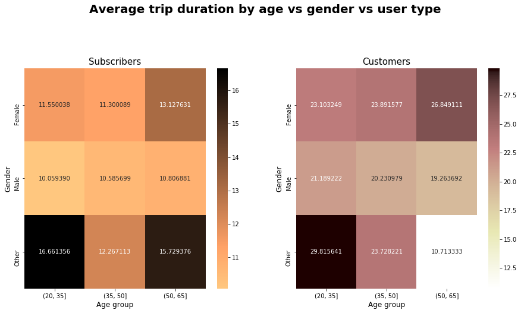

```python
plt.figure(figsize=(15,15))
plt.subplot(221)
plt.suptitle('Average trip duration by age vs gender vs user type', fontsize=20, fontweight='bold')
sb.heatmap(df_subscriber_Av_duration, annot = True, fmt='f', cmap='copper_r');
plt.title("Subscribers", fontsize=15, y=1.12)
plt.xlabel('Age group', fontsize=12)
plt.ylabel('Gender', fontsize=12);

plt.subplot(222)
sb.heatmap(df_customer_Av_duration, annot = True, fmt='f', cmap='pink_r');
plt.title("Customers", fontsize=15, y=1.12)
plt.xlabel('Age group', fontsize=12)
plt.ylabel('Gender', fontsize=12);
```

## Bike usage by user gender

> Males use the bike-sharing system most. Then females use it and a very less amount of other gender people use the bike-sharing system.

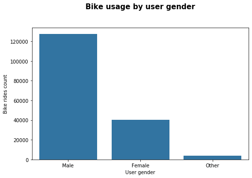

```python
plt.figure(figsize=[8, 5])
#sb.countplot(data=bike_data_copy, x="member_gender", color = base_color)
freq = bike_data_copy['member_gender'].value_counts()
user_order = freq.index
sb.countplot(data=bike_data_copy, x='member_gender', color=base_color, order=user_order);
plt.title('Bike usage by user gender', fontsize=15, fontweight='bold', y=1.12)
plt.xlabel('User gender')
plt.ylabel('Bike rides count')
plt.show();
```

## Bike usage pattern during the week by user type

> Customers bike usage frequency is very low when compared with subscribers. Subscribers bike usage has dropped during the weekend. On the other hand customers are using bikes in both weekdays and weekends.

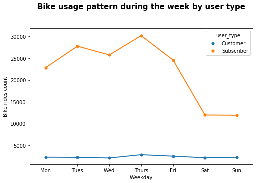

```python
#Investigating the bike usage trend during the week by the user type
df_bike_data_user_week = bike_data_copy.groupby(['start_day', 'user_type']).size().reset_index()
plt.figure(figsize=[8, 5])
sb.pointplot(data=df_bike_data_user_week, x='start_day', y=0 , hue = 'user_type', scale=.7);
ticks =  [0,1,2,3,4,5,6]
labels = ['Mon', 'Tues', 'Wed', 'Thurs', 'Fri', 'Sat', 'Sun']
plt.xticks(ticks,labels)
plt.title('Bike usage pattern during the week by user type', fontsize=15, fontweight='bold',y=1.12)
plt.xlabel('Weekday')
plt.ylabel('Bike rides count')
plt.show();
```

## Bike usage pattern of subscribers in each hour during the week by age group

> Subscribers' bike usage is high from 7-9 am and 4-7 pm on weekdays. 50-65 aged subscribers bike usage is low when compared with other subscribers. Subscribers' weekend bike usage is very low when compared with weekdays.

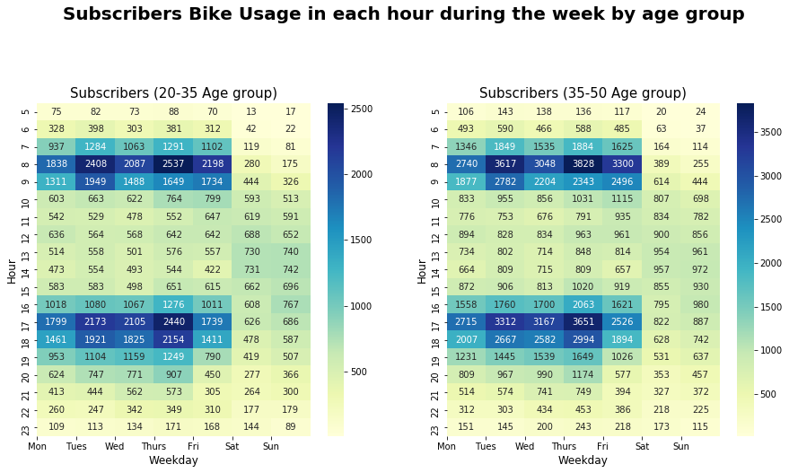

```python
plt.figure(figsize=(15,15))
plt.subplot(221)
plt.suptitle(' Subscribers Bike Usage in each hour during the week by age group', fontsize=20, fontweight='bold')
sb.heatmap(df_subscriber_age20, annot = True, fmt='d', cmap="YlGnBu")
plt.title("Subscribers (20-35 Age group)", fontsize=15)
plt.xlabel('Weekday', fontsize=12)
plt.ylabel('Hour', fontsize=12)
ticks =  [0,1,2,3,4,5,6]
labels = ['Mon', 'Tues', 'Wed', 'Thurs', 'Fri', 'Sat', 'Sun']
plt.xticks(ticks,labels);
plt.subplot(222)
sb.heatmap(df_subscriber_age35, annot = True, fmt='d', cmap='YlGnBu');
plt.title("Subscribers (35-50 Age group)", fontsize=15)
plt.xlabel('Weekday', fontsize=12)
plt.ylabel('Hour', fontsize=12)
plt.xticks(ticks,labels);
```

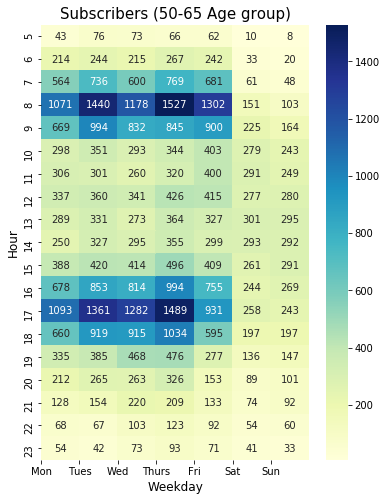

```python
plt.figure(figsize=(6,8))
sb.heatmap(df_subscriber_age45, annot = True, fmt='d', cmap='YlGnBu');
plt.title("Subscribers (50-65 Age group)", fontsize=15)
plt.xlabel('Weekday', fontsize=12)
plt.ylabel('Hour', fontsize=12)
plt.xticks(ticks,labels);
```

## Bike usage pattern of customers in each hour during the week by age group

> Customers' bike usage is high from 7-9 am and 4-6 pm on weekdays and 10 am - 5 pm on weekends. 50-65 aged customers use bikes during the daytime of weekdays. 50-65 aged customers bike usage is low when compared with other customers.

[figure not shown]

```python
plt.figure(figsize=(15,15))
plt.subplot(221)
plt.suptitle('Customers Bike Usage in each hour during the week by age group', fontsize=20, fontweight='bold')
sb.heatmap(df_customer1_age20, annot = True, fmt='.1f', cmap='YlOrBr')
plt.title("Customers (20-35 Age group)", fontsize=15)
plt.xlabel('Weekday', fontsize=12)
plt.ylabel('Hour', fontsize=12)
ticks =  [0,1,2,3,4,5,6]
labels = ['Mon', 'Tues', 'Wed', 'Thurs', 'Fri', 'Sat', 'Sun']
plt.xticks(ticks,labels);
plt.subplot(222)
sb.heatmap(df_customer2_age35, annot = True, fmt='.1f', cmap='YlOrBr')
plt.title("Customers (35-50 Age group)", fontsize=15)
plt.xlabel('Weekday', fontsize=12)
plt.ylabel('Hour', fontsize=12)
plt.xticks(ticks,labels);
```

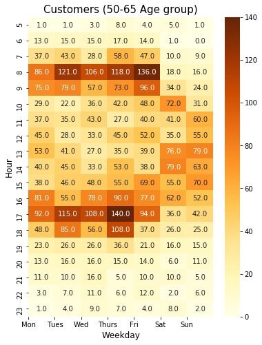

```python
plt.figure(figsize=(6,8))
sb.heatmap(df_customer3_age40, annot = True, fmt='.1f', cmap='YlOrBr')
plt.title("Customers (50-65 Age group)", fontsize=15)
plt.xlabel('Weekday', fontsize=12)
plt.ylabel('Hour', fontsize=12)
plt.xticks(ticks,labels);
```

## Conclusion

> When we consider the bike usage trend of users we can conclude,
> - Subscribers use the bike-sharing system more than customers.
> - Males use the bike-sharing system most.
> - There is a high demand for bikes during 7-9 am and 4-6 pm during weekdays from all users. This implies both users use bikes for commute purposes.
> - Customers have a high demand for bikes during the weekend daytime.
> - Bike usage of users over 50 years is less when compared to other users.

## Conclusion

> It is interesting to find that, the users who use the bike-sharing system more frequently use it for shorter trips and users who use the bike-sharing system less frequently use it for longer trips.